# MAESTRIA EN DATA MINING - TP AID

MARIA JOSE FERREYRA VILLANUEVA

Ago 2020

##### ASIGNACION DE BASES:

**NO SUPERVISADA** <- base telecomunicaciones, seleccionar 5 variables cualesquiera.

##### ANALISIS NO SUPERVISADO: TELECOMUNICACIONES

Levantamos el conjunto de datos y vemos su estructura y contenido.

```r
# levantamos el dataset
df_tele <- read.csv("telecomunicaciones.csv", sep=";", stringsAsFactors = FALSE)

dim(df_tele)
```

```
## [1] 1000   36
```

```r
summary(df_tele)
```

```
##      region       permanencia         edad        estado_civil
##  Min.   :1.000   Min.   : 1.00   Min.   :18.00   Min.   :0.000
##  1st Qu.:1.000   1st Qu.:17.00   1st Qu.:32.00   1st Qu.:0.000
##  Median :2.000   Median :34.00   Median :40.00   Median :0.000
##  Mean   :2.022   Mean   :35.53   Mean   :41.68   Mean   :0.495
##  3rd Qu.:3.000   3rd Qu.:54.00   3rd Qu.:51.00   3rd Qu.:1.000
##  Max.   :3.000   Max.   :72.00   Max.   :77.00   Max.   :1.000
##    dirección     ingresos_familiares nivel_educativo     empleo
##  Min.   : 0.00   Min.   :   9.00     Min.   :1.000   Min.   : 0.00
##  1st Qu.: 3.00   1st Qu.:  29.00     1st Qu.:2.000   1st Qu.: 3.00
##  Median : 9.00   Median :  47.00     Median :3.000   Median : 8.00
##  Mean   :11.55   Mean   :  77.53     Mean   :2.671   Mean   :10.99
##  3rd Qu.:18.00   3rd Qu.:  83.00     3rd Qu.:4.000   3rd Qu.:17.00
##  Max.   :55.00   Max.   :1668.00     Max.   :5.000   Max.   :47.00
##     jubilado         genero       n_pers_hogar   llamada_gratuitas
##  Min.   :0.000   Min.   :0.000   Min.   :1.000   Min.   :0.000
##  1st Qu.:0.000   1st Qu.:0.000   1st Qu.:1.000   1st Qu.:0.000
##  Median :0.000   Median :1.000   Median :2.000   Median :0.000
##  Mean   :0.047   Mean   :0.517   Mean   :2.331   Mean   :0.474
##  3rd Qu.:0.000   3rd Qu.:1.000   3rd Qu.:3.000   3rd Qu.:1.000
##  Max.   :1.000   Max.   :1.000   Max.   :8.000   Max.   :1.000
##  alquiler_equipo tarjeta_llamada  Inhalámbrico   larga_distancia_mes
##  Min.   :0.000   Min.   :0.000   Min.   :0.000   Min.   : 0.900
##  1st Qu.:0.000   1st Qu.:0.000   1st Qu.:0.000   1st Qu.: 5.200
##  Median :0.000   Median :1.000   Median :0.000   Median : 8.525
##  Mean   :0.386   Mean   :0.678   Mean   :0.296   Mean   :11.723
##  3rd Qu.:1.000   3rd Qu.:1.000   3rd Qu.:1.000   3rd Qu.:14.412
##  Max.   :1.000   Max.   :1.000   Max.   :1.000   Max.   :99.950
##  llamadas_gratuitas_mes   equipo_mes     Tarjeta_mes     inhalámbrico_mes
##  Min.   :  0.00         Min.   : 0.00   Min.   :  0.00   Min.   :  0.00
##  1st Qu.:  0.00         1st Qu.: 0.00   1st Qu.:  0.00   1st Qu.:  0.00
##  Median :  0.00         Median : 0.00   Median : 12.00   Median :  0.00
##  Mean   : 13.27         Mean   :14.22   Mean   : 13.78   Mean   : 11.58
##  3rd Qu.: 24.25         3rd Qu.:31.48   3rd Qu.: 20.50   3rd Qu.: 24.71
##  Max.   :173.00         Max.   :77.70   Max.   :109.25   Max.   :111.95
##  larga_distancia_per llamadas_gratuitas_per  equipos_per      tarjeta_per
##  Min.   :   0.90     Min.   :   0.0         Min.   :   0.0   Min.   :   0.0
##  1st Qu.:  90.14     1st Qu.:   0.0         1st Qu.:   0.0   1st Qu.:   0.0
##  Median : 285.48     Median :   0.0         Median :   0.0   Median : 332.5
##  Mean   : 574.05     Mean   : 551.3         Mean   : 465.6   Mean   : 605.8
```

[output cut: 8 more lines]

```
##  Max.   :7856.9   Max.   :1.000    Max.   :1.000   Max.   :1.000
##     internet     identificador_llamada llamada_espera  desvio_llamadas
##  Min.   :0.000   Min.   :0.000         Min.   :0.000   Min.   :0.000
##  1st Qu.:0.000   1st Qu.:0.000         1st Qu.:0.000   1st Qu.:0.000
##  Median :0.000   Median :0.000         Median :0.000   Median :0.000
##  Mean   :0.368   Mean   :0.481         Mean   :0.485   Mean   :0.493
##  3rd Qu.:1.000   3rd Qu.:1.000         3rd Qu.:1.000   3rd Qu.:1.000
##  Max.   :1.000   Max.   :1.000         Max.   :1.000   Max.   :1.000
##  llamada_a_tres  facturación_electrónica categoria_cliente  rotación_mes
##  Min.   :0.000   Min.   :0.000           Min.   :1.000     Min.   :0.000
##  1st Qu.:0.000   1st Qu.:0.000           1st Qu.:1.000     1st Qu.:0.000
##  Median :1.000   Median :0.000           Median :3.000     Median :0.000
##  Mean   :0.502   Mean   :0.371           Mean   :2.487     Mean   :0.274
##  3rd Qu.:1.000   3rd Qu.:1.000           3rd Qu.:3.000     3rd Qu.:1.000
##  Max.   :1.000   Max.   :1.000           Max.   :4.000     Max.   :1.000
```

```r
str(df_tele)
```

```
## 'data.frame':    1000 obs. of  36 variables:
##  $ region                 : int  2 3 3 2 2 2 3 2 3 1 ...
##  $ permanencia            : int  13 11 68 33 23 41 45 38 45 68 ...
##  $ edad                   : int  44 33 52 33 30 39 22 35 59 41 ...
##  $ estado_civil           : int  1 1 1 0 1 0 1 0 1 1 ...
##  $ dirección              : int  9 7 24 12 9 17 2 5 7 21 ...
##  $ ingresos_familiares    : int  64 136 116 33 30 78 19 76 166 72 ...
##  $ nivel_educativo        : int  4 5 1 2 1 2 2 2 4 1 ...
##  $ empleo                 : int  5 5 29 0 2 16 4 10 31 22 ...
##  $ jubilado               : int  0 0 0 0 0 0 0 0 0 0 ...
##  $ genero                 : int  0 0 1 1 0 1 1 0 0 0 ...
##  $ n_pers_hogar           : int  2 6 2 1 4 1 5 3 5 3 ...
##  $ llamada_gratuitas      : int  0 1 1 0 0 1 0 1 1 0 ...
##  $ alquiler_equipo        : int  0 0 0 0 0 0 0 1 0 0 ...
##  $ tarjeta_llamada        : int  1 1 1 0 0 1 1 1 1 1 ...
```

[output cut: 22 more lines]

Seleccion de variables

```r
df_tele <- df_tele[,c('permanencia','llamadas_gratuitas_mes','inhalámbrico_mes','n_pers_hogar','edad')]
```

##### ANALISIS EXPLORATORIO

Boxplots de las variables elegidas

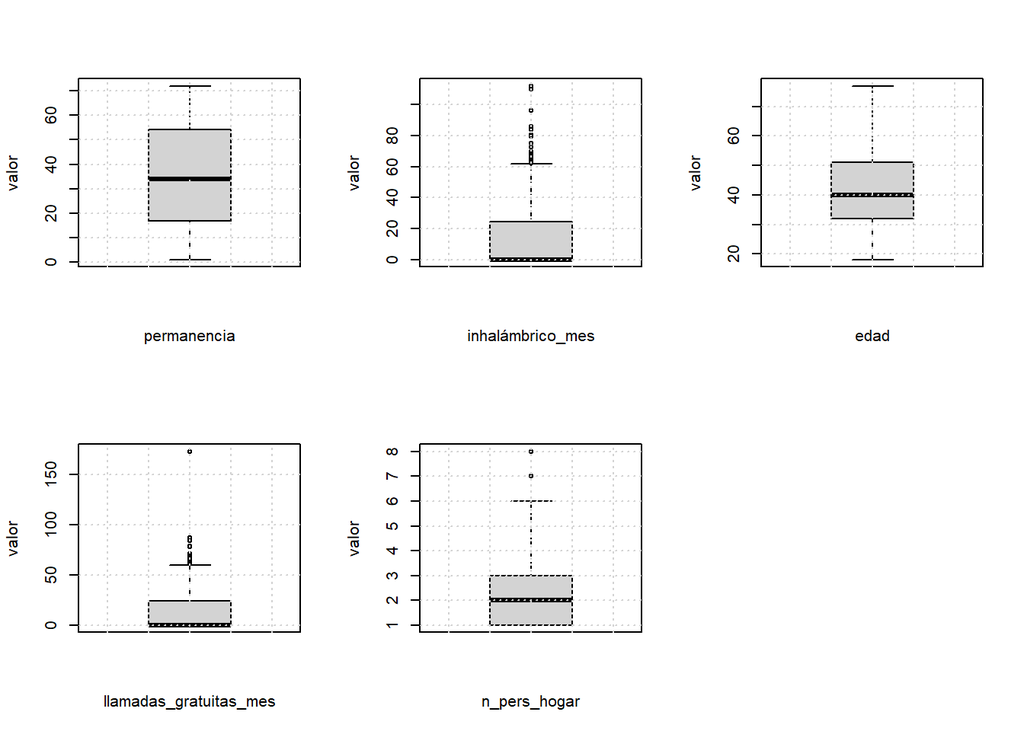

```r
par(mfcol = c(2,3))

for (col in 1:ncol(df_tele)){
  boxplot(df_tele[,col],
          xlab = names(df_tele)[col],
          ylab = "valor")
  grid()
}
```

Vemos la relacion entre las variables: Correlograma

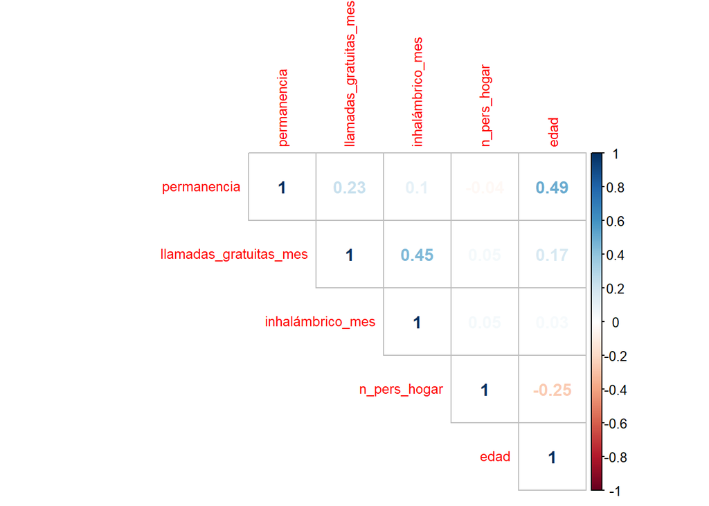

```r
cor.1<-cor(df_tele[1:5])

corrplot(cor.1,method="number", type="upper",  tl.cex = 0.8)
```

Analisis de componentes principales. Grafico y tabla de loadings

```r
datos.pc = prcomp(df_tele[1:5],scale = TRUE)

#cargas
round(datos.pc$rotation,2)
```

```
##                          PC1   PC2   PC3   PC4   PC5
## permanencia             0.55 -0.22  0.47 -0.22 -0.62
## llamadas_gratuitas_mes  0.50  0.44 -0.14  0.73 -0.09
## inhalámbrico_mes        0.38  0.56 -0.33 -0.65  0.12
## n_pers_hogar           -0.15  0.50  0.80 -0.02  0.29
## edad                    0.53 -0.44  0.11  0.01  0.72
```

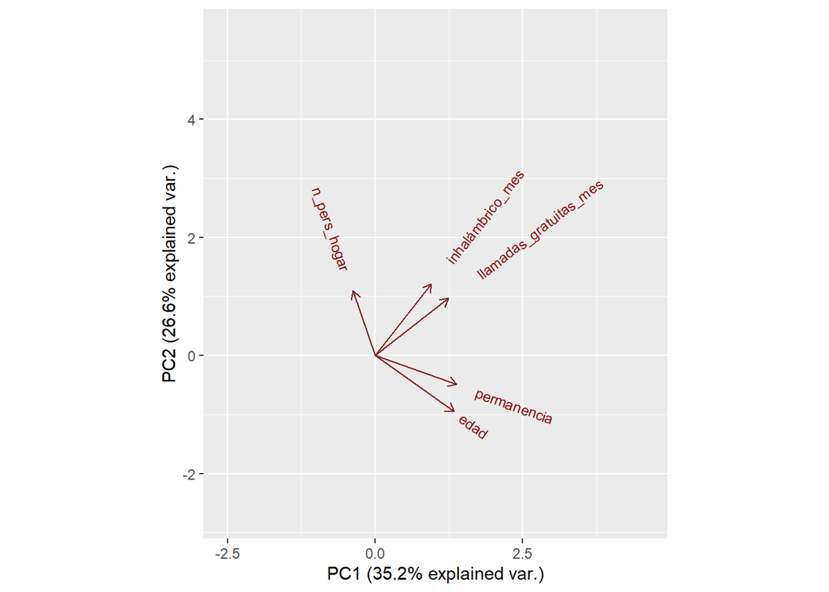

```r
#grafico
ggbiplot(datos.pc, obs.scale=1 ,var.scale=1,alpha=0.0)
```

##### ALGORITMO KMEANS NO JERARQUICO

Graficos de Silhouette y de Suma de Cuadrados Dentro para la seleccion optima de cantidad de clusters

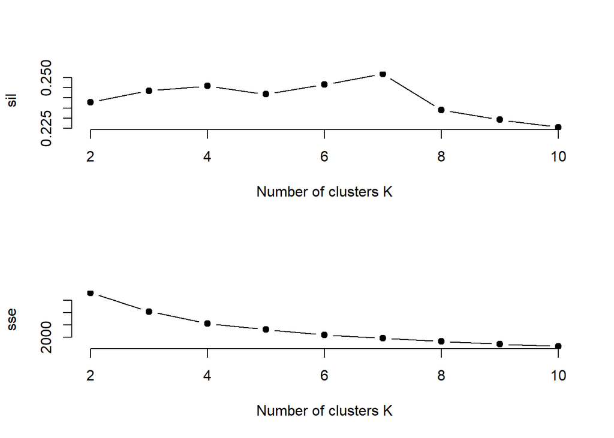

```r
kmax =10

#escalamiento
m1   = metrica(scale(df_tele),kmax,"kmeans")

#graficos de los indicadores de clustering
par(mfrow=c(2,1))
plot(2:kmax, m1$sil[2:kmax],col=1,type="b", pch = 19, frame = FALSE,
     xlab="Number of clusters K",
     ylab="sil")

plot(2:kmax, m1$sse[2:kmax],type="b", pch = 19, frame = FALSE,
     xlab="Number of clusters K",
     ylab="sse")
```

```r
par(mfrow=c(1,1))
```

```r
#Realizamos 3 grupos, tal cual sugieren los graficos
CL  = kmeans(scale(df_tele),3,nstart=50,iter.max = 10)

df_tele$kmeans = CL$cluster

table(df_tele$kmeans)
```

```
##
##   1   2   3
## 364 186 450
```

Visualizamos los clusters en el biplot

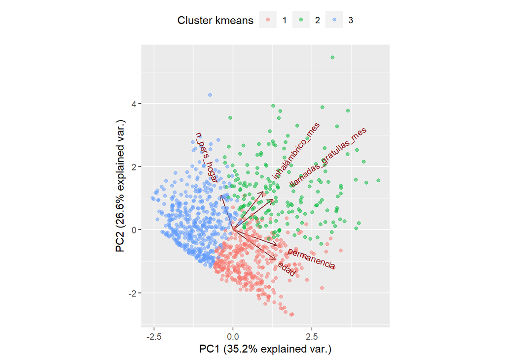

```r
# visualizamos los cluster obtenidos en el biplot

ggbiplot(datos.pc, obs.scale=1 ,var.scale=1, alpha=0.5,groups = as.factor(df_tele$kmeans)) +
      scale_colour_discrete(name="Cluster kmeans") +
      theme(legend.direction ="horizontal", legend.position = "top")
```

##### ALGORITMOS JERARQUICO

Comparamos distintos algoritmos. Usamos la distancia de *manhattan*y escalamiento por *maximos y minimos*

```r
#cluster jerárquico
datos2<-df_tele[,1:5]
#quito columna "kmeans"

datos2 <-apply(datos2,2,esc01)

# Matriz de distancias de manhattan
mat_dist <- dist(x = datos2, method = "manhattan")

# Dendrogramas (según el tipo de segmentación jerárquica aplicada)
hc_complete <- hclust(d = mat_dist, method = "complete")
hc_average  <- hclust(d = mat_dist, method = "average")
hc_single   <- hclust(d = mat_dist, method = "single")
hc_ward     <- hclust(d = mat_dist, method = "ward.D2")

#calculo del coeficiente de correlacion cofenetico
cor(x = mat_dist, cophenetic(hc_complete))
```

```
## [1] 0.4889359
```

```r
cor(x = mat_dist, cophenetic(hc_average))
```

```
## [1] 0.6136286
```

```r
cor(x = mat_dist, cophenetic(hc_single))
```

```
## [1] 0.4684972
```

```r
cor(x = mat_dist, cophenetic(hc_ward))
```

```
## [1] 0.5183545
```

Analizamos los coeficientes de correlacion cofenetica. El algoritmo de Average es el que tiene el mayor valor.  
Graficamos el dendograma del modelo Average.

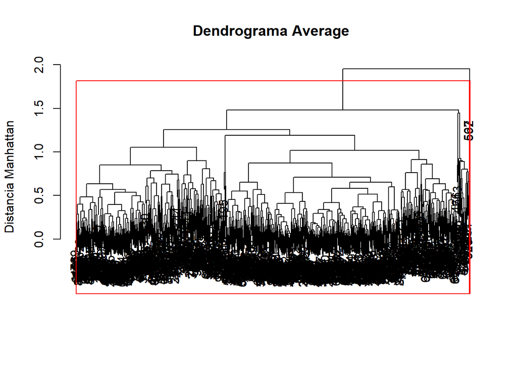

```r
# Dendograma usando los resultados de la técnica de average
# la tecnica tiene el mayor coeficiente cofenetico
plot(hc_average , main="Dendrograma Average ", xlab = "", sub="", ylab = "Distancia Manhattan")

#con 2 grupos podria ser la mejor eleccion
rect.hclust(hc_average, k=2, border="red")
```

```r
grupos<-cutree(hc_average,k=2)

# los cluster quedan muy desbalanceados
table(grupos)
```

```
## grupos
##   1   2
## 998   2
```

Los cluster estan demasiado desbalanceados. A partir del análisis grafico, 2 clusters serían la mejor eleccion.  
Buscamos otra opción, el algoritmo de Ward, tiene el segundo mejor coeficiente cofenetico.  
Graficamos el dendrograma:

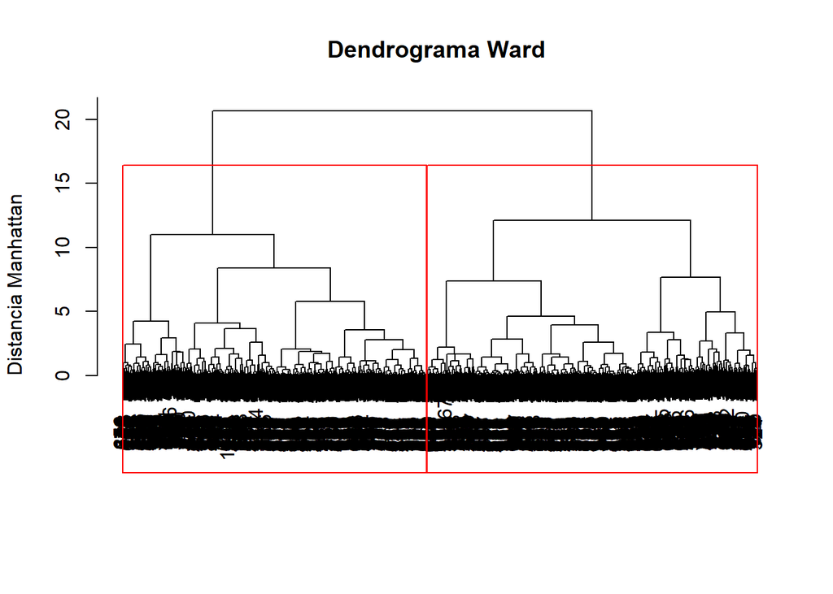

```r
# Dendograma usando los resultados de la técnica de ward

plot(hc_ward , main="Dendrograma Ward ", xlab = "", sub="", ylab = "Distancia Manhattan")

# graficamente, se aprecia que 2 clusters sería la mejor eleccion
rect.hclust(hc_ward, k=2, border="red")
```

```r
grupos<-cutree(hc_ward,k=2)
par(xpd=TRUE)
# los grupos se ven bastante balanceados
table(grupos)
```

```
## grupos
##   1   2
## 521 479
```

Los cluster se ven mas balanceados y en el dendrograma es mas facil verificar que la cantidad optima de clusters es 2.

Visualizamos los clusters obtenidos en el biplot

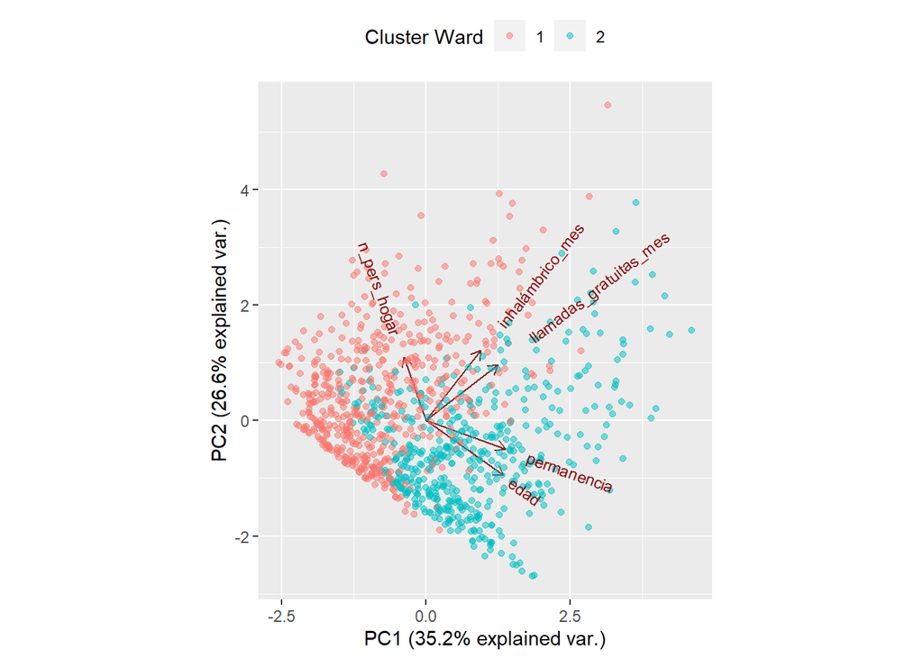

```r
#visualizamos con 3 grupos el cluster jerarquico Ward
ggbiplot(datos.pc, obs.scale=1 ,var.scale=1, alpha=0.5,groups = as.factor(grupos) )+
  scale_colour_discrete(name="Cluster Ward") +
theme(legend.direction ="horizontal", legend.position = "top")
```

###### Maria Jose Ferreyra V. Agosto 2020